# Problem Set 3

### 2.7d

Here I added a blue smooth trend line using `geom_smooth()` because it makes it easier to see how gas production changed over time

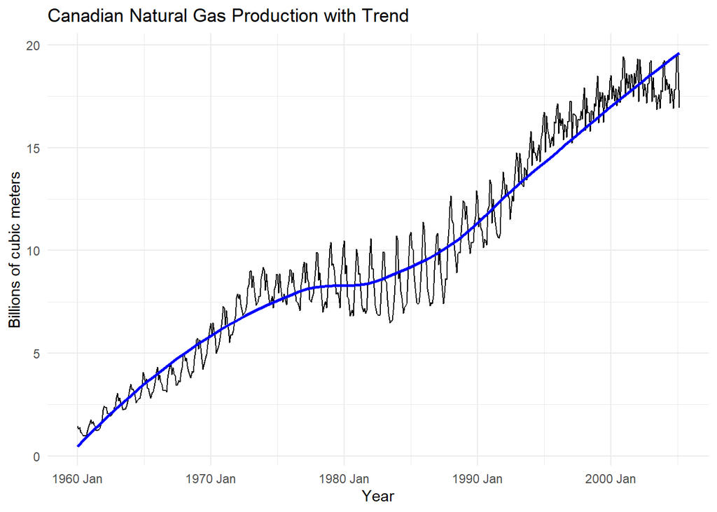

```r
can_gas |>
  autoplot(Volume) +
  geom_smooth(method = "loess", se = FALSE, color = "blue") +
  labs(
    title = "Canadian Natural Gas Production with Trend",
    x = "Year",
    y = "Billions of cubic meters"
  ) +
  theme_minimal()
```

### 3.1a

In the graph I noticed that the seasonal ups and downs generally become larger as gas production increases, especially during the 1970s and 1980s., but this doesn’t happen throughout the entire period. Towards the end, production keeps increasing, but the seasonal changes don’t grow as much as before

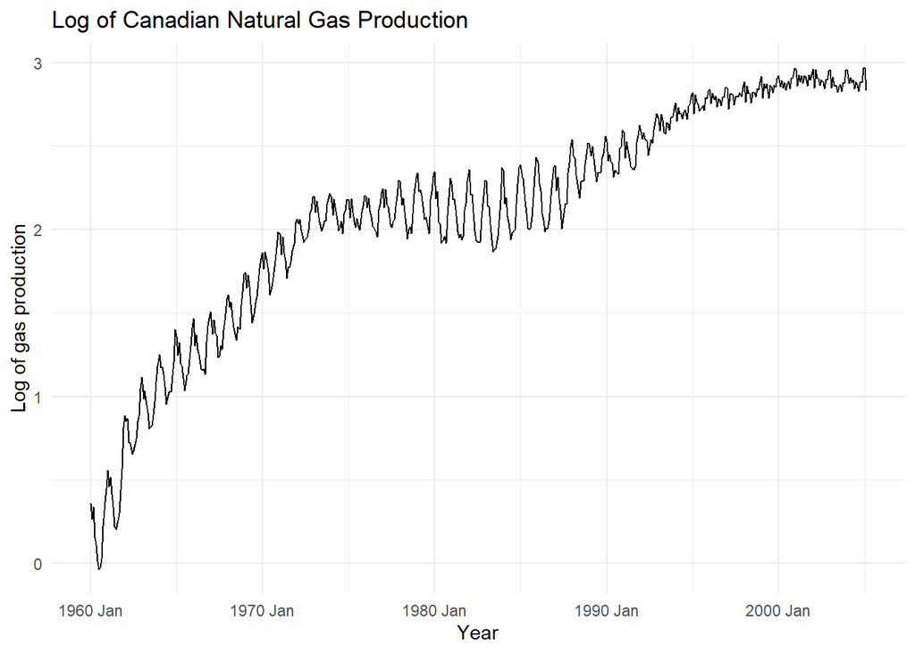

Figure 1: Log-transformed Canadian natural gas production

```r
can_gas <- can_gas |>
  mutate(log_volume = log(Volume))

can_gas |>
  autoplot(log_volume) +
  labs(
    title = "Log of Canadian Natural Gas Production",
    x = "Year",
    y = "Log of gas production"
  ) +
  theme_minimal()
```

### 3.1b

After taking the log of gas production, I see that the trend becomes flatter and the seasonal ups and downs look more balanced, especially when production is higher. However, seasonal changes are still visible and their size is not completely constant over time. I think using logs is helpful because it makes the changes easier to compare, even though it doesn’t completely remove the differences in seasonal fluctuations

### 3.1c

By looking at the two graphs we know that retail sales keep increasing over time, and the seasonal ups and downs become larger as sales grow. After taking the log, the trend looks more linear and the seasonal changes become more balanced. Here I think using logs makes even more sense for retail sales than for Canadian gas production because the seasonal fluctuations seem to grow more consistently with the level of sales

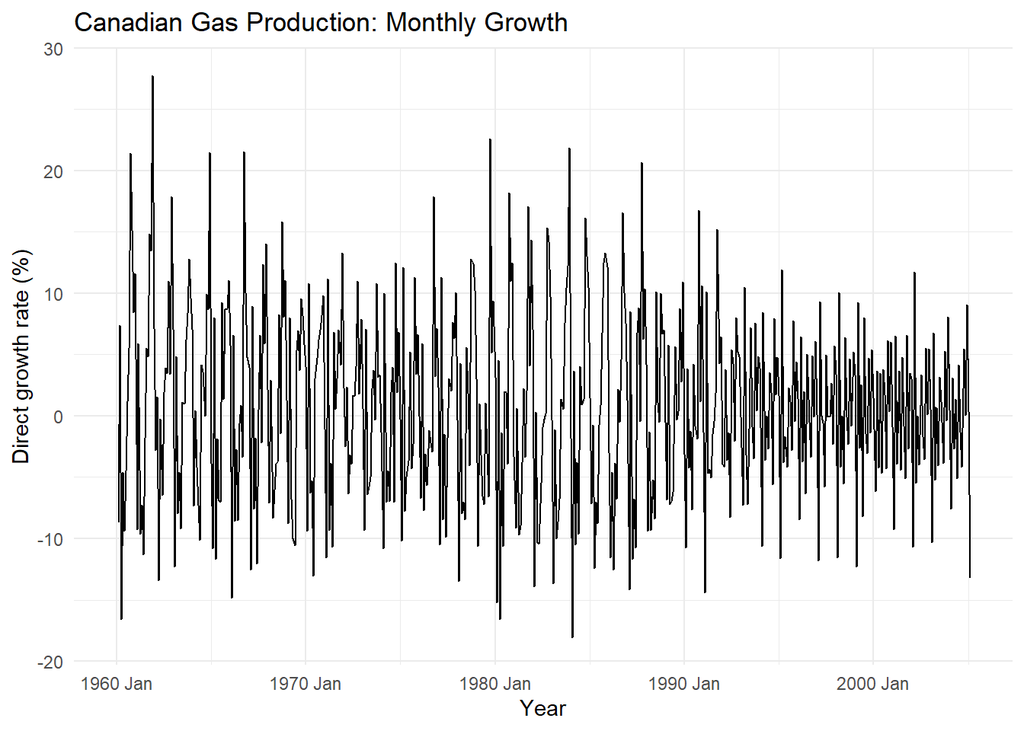

```r
can_gas <- can_gas |>
  mutate(
    growth_direct = 100 * difference(Volume) / lag(Volume),
    growth_logdiff = 100 * difference(log(Volume)),
    growth_gap = abs(growth_direct - growth_logdiff)
  )

can_gas |>
  autoplot(growth_direct) +
  labs(
    title = "Canadian Gas Production: Monthly Growth",
    x = "Year",
    y = "Direct growth rate (%)"
  ) +
  theme_minimal()
```

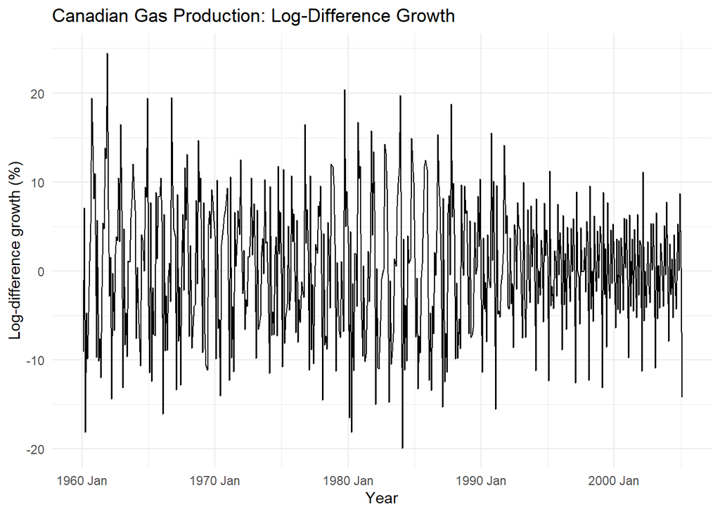

```r
can_gas |>
  autoplot(growth_logdiff) +
  labs(
    title = "Canadian Gas Production: Log-Difference Growth",
    x = "Year",
    y = "Log-difference growth (%)"
  ) +
  theme_minimal()
```

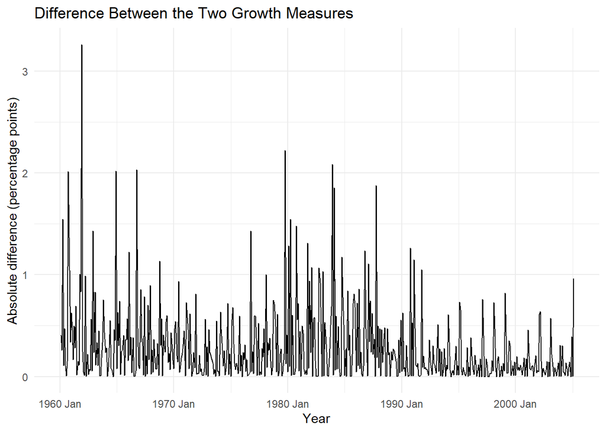

```r
can_gas |>
  autoplot(growth_gap) +
  labs(
    title = "Difference Between the Two Growth Measures",
    x = "Year",
    y = "Absolute difference (percentage points)"
  ) +
  theme_minimal()
```

### 3.2a

The difference between the two methods is usually very small and close to zero. There are some larger spikes, especially in the earlier years, but overall I think the log difference is a good approximation of the actual growth rate, particularly when monthly changes are small

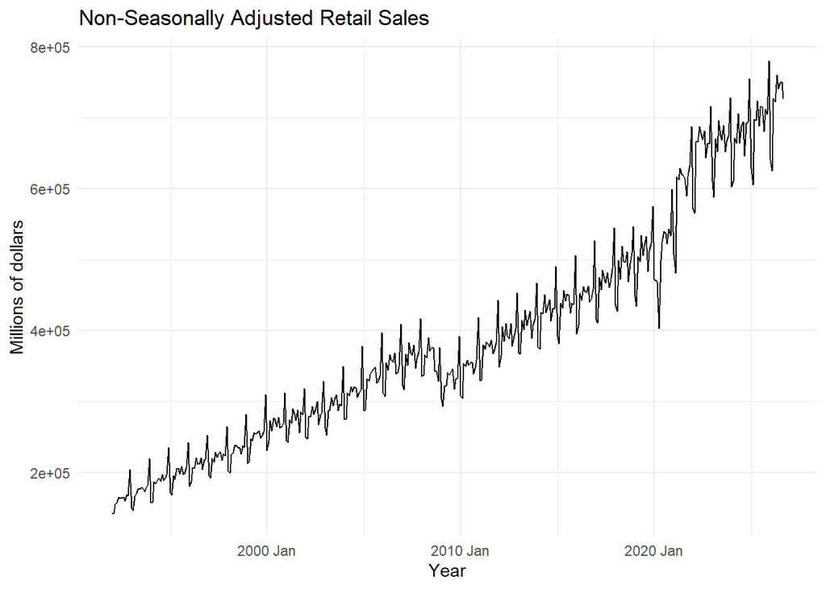

```r
retail_nsa <- retail_ts |>
  filter(series_id == "RSAFSNA") |>
  mutate(log_sales = log(sales))

retail_nsa |>
  autoplot(sales) +
  labs(
    title = "Non-Seasonally Adjusted Retail Sales",
    x = "Year",
    y = "Millions of dollars"
  ) +
  theme_minimal()
```

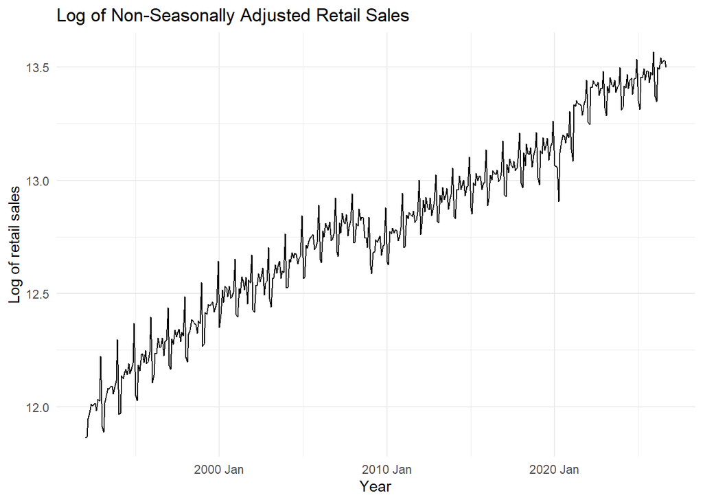

```r
retail_nsa |>
  autoplot(log_sales) +
  labs(
    title = "Log of Non-Seasonally Adjusted Retail Sales",
    x = "Year",
    y = "Log of retail sales"
  ) +
  theme_minimal()
```

### 3.3

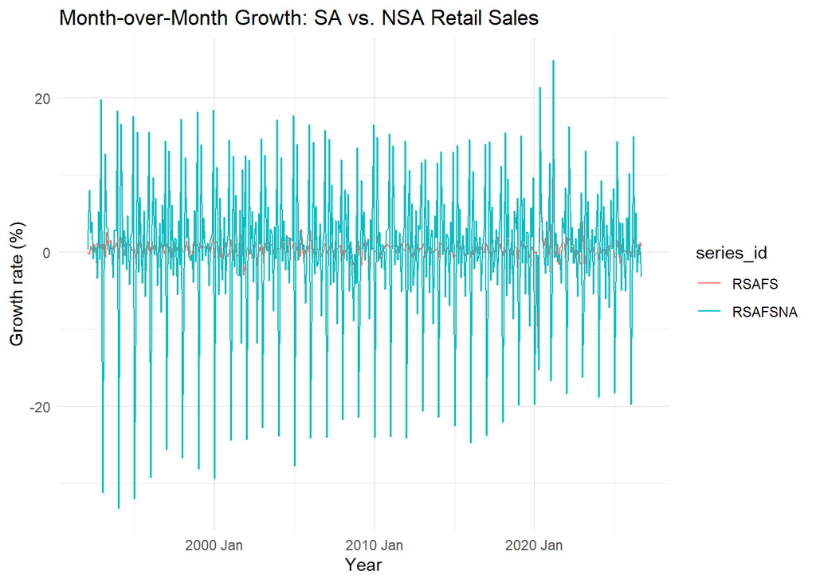

```r
retail_ts <- retail_ts |>
  group_by_key() |>
  mutate(
    growth_mom = 100 * difference(log(sales))
  ) |>
  ungroup()

retail_ts |>
  autoplot(growth_mom) +
  labs(
    title = "Month-over-Month Growth: SA vs. NSA Retail Sales",
    x = "Year",
    y = "Growth rate (%)",
    color = NULL
  ) +
  theme_minimal()
```

### 4.1a

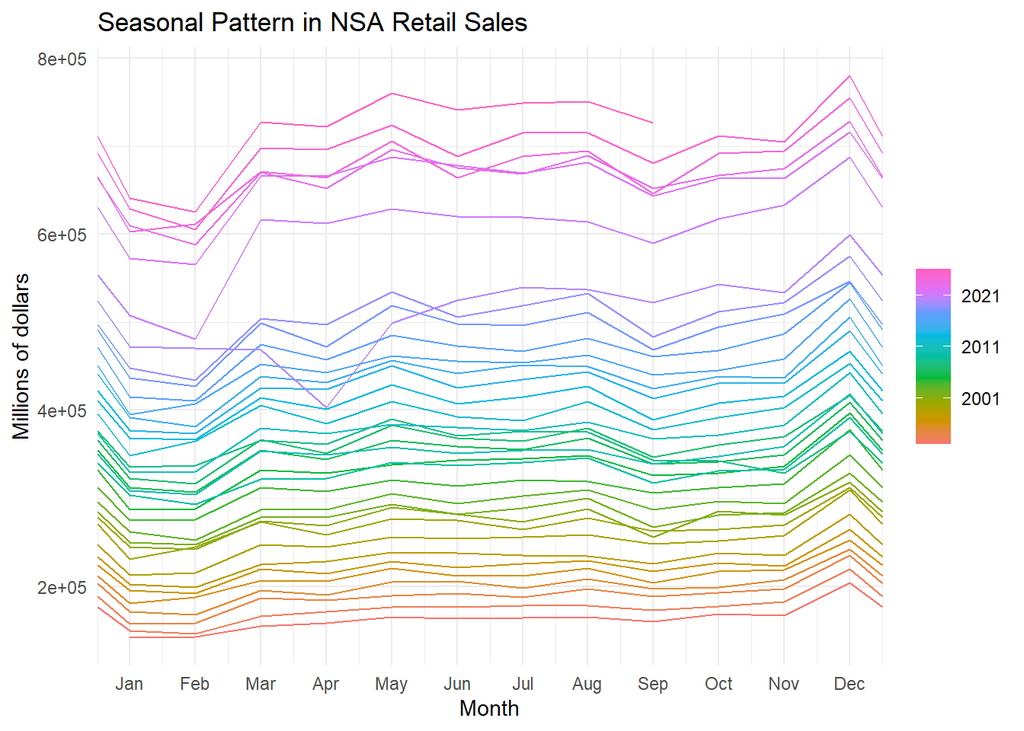

```r
retail_ts |>
  filter(series_id == "RSAFSNA") |>
  gg_season(sales) +
  labs(
    title = "Seasonal Pattern in NSA Retail Sales",
    x = "Month",
    y = "Millions of dollars"
  ) +
  theme_minimal()
```

### 4.1b

The difference between the two series is pretty clear: In the non-seasonally adjusted data, sales tend to increase in December and drop again at the beginning of the year. After seasonal adjustment, these repeating changes mostly disappear and the lines become much flatter, and this helps me see the changes in sales without the usual seasonal effects

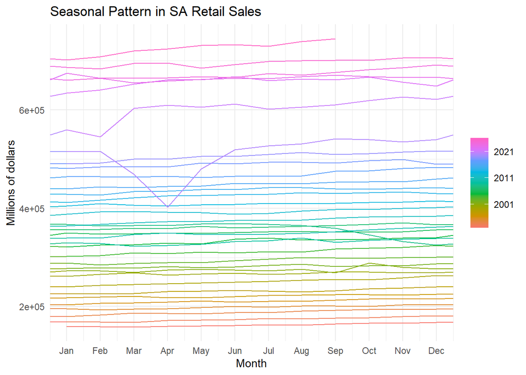

```r
retail_ts |>
  filter(series_id == "RSAFS") |>
  gg_season(sales) +
  labs(
    title = "Seasonal Pattern in SA Retail Sales",
    x = "Month",
    y = "Millions of dollars"
  ) +
  theme_minimal()
```

### 4.1c

Canadian gas production follows a fairly clear seasonal pattern, with higher levels in December and January and lower levels during the summer, especially around June and July. This makes sense to me because Canada has very cold winters, when people use more natural gas for heating. Even though production changes over the years, this seasonal pattern is still noticeable

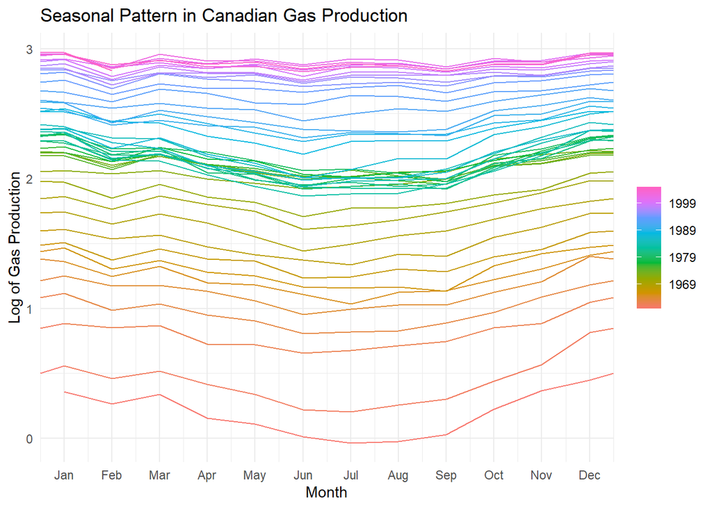

```r
can_gas |>
  gg_season(log_volume) +
  labs(
    title = "Seasonal Pattern in Canadian Gas Production",
    x = "Month",
    y = "Log of Gas Production"
  ) +
  theme_minimal()
```